# Practical Machine Learning Assignment

Surabh

7/20/2021

## Executive Summary

Using devices such as Jawbone Up, Nike FuelBand, and Fitbit it is now possible to collect a large amount of data about personal activity relatively inexpensively. In this project, the goal will be to use data from accelerometers on the belt, forearm, arm, and dumbell of 6 participants. They were asked to perform barbell lifts correctly and incorrectly in 5 different ways. More information is available from the website here: http://web.archive.org/web/20161224072740/http:/groupware.les.inf.puc-rio.br/har

Data downloaded from: Training Data: https://d396qusza40orc.cloudfront.net/predmachlearn/pml-training.csv

Testing Data: https://d396qusza40orc.cloudfront.net/predmachlearn/pml-testing.csv

## Data Load

First we download the data.

```r
library(caret)
```

```r
#Set Working Directory to relevant folder
setwd("~/Coursera/Practical Machine Learning/Week 4/Assignment")
trainURL <- "http://d396qusza40orc.cloudfront.net/predmachlearn/pml-training.csv"
testURL <- "http://d396qusza40orc.cloudfront.net/predmachlearn/pml-testing.csv"
training <- read.csv(url(trainURL))
testing <- read.csv(url(testURL))

dim(training)
```

```
## [1] 19622   160
```

```r
dim(testing)
```

```
## [1]  20 160
```

## Exploratory Data Analysis

Then we split the training data to train and test sub-groups. We will only use the “testing” data for final validation.

```r
library(caret)
indexTrain <- createDataPartition(training$classe, p = 0.7, list = FALSE)
trainSet <- training[indexTrain, ]
testSet <- training[-indexTrain, ]
```

We do all our exploratory data analysis on the train sub-group.

```r
str(trainSet)
head(trainSet,n=3)
summary(trainSet)
```

[output not shown]

We can see that there are some near zero variables and variables that contain lots of NA. We can exclude them from our prediction model.

```r
NZV <- nearZeroVar(trainSet)
trainSet <- trainSet[ ,-NZV]
testSet <- testSet[ ,-NZV]
label <- apply(trainSet, 2, function(x) mean(is.na(x))) > 0.95
trainSet <- trainSet[, -which(label, label == FALSE)]
testSet <- testSet[, -which(label, label == FALSE)]
trainSet <- trainSet[ , -(1:5)]
testSet <- testSet[ , -(1:5)]
```

We can now do some correlation plots.

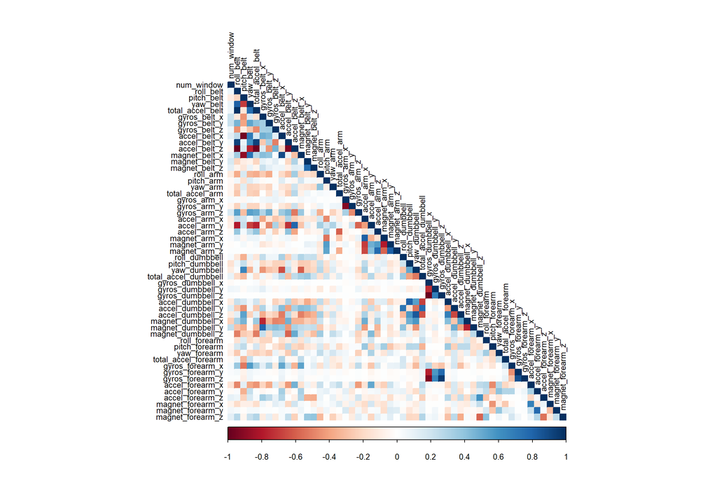

```r
library(corrplot)
corrMat <- cor(trainSet[,-54])
corrplot(corrMat, method = "color", type = "lower", tl.cex = 0.8, tl.col = rgb(0,0,0))
```

We could do some Principle Component Analysis to further reduce the correlated variables to improve our model in future studies.Although, there are not that many highly correlated variables so that will not impact our prediction models significantly.

## Prediction Model Selection

We will predict with Decision Tree (rpart), Random Forest(rf) and Generalized Boosted Model (gbm).

### Decision Tree

```r
library(caret)
library(e1071)
library(rattle)
set.seed(123)
modelDT <- train(classe ~ ., data = trainSet, method = "rpart")
modelDT$finalModel
```

```
## n= 13737
##
## node), split, n, loss, yval, (yprob)
##       * denotes terminal node
##
##  1) root 13737 9831 A (0.28 0.19 0.17 0.16 0.18)
##    2) roll_belt< 130.5 12575 8679 A (0.31 0.21 0.19 0.18 0.11)
##      4) pitch_forearm< -33.95 1086    6 A (0.99 0.0055 0 0 0) *
##      5) pitch_forearm>=-33.95 11489 8673 A (0.25 0.23 0.21 0.2 0.12)
##       10) num_window>=45.5 10983 8167 A (0.26 0.24 0.22 0.2 0.088)
##         20) magnet_dumbbell_y< 439.5 9385 6625 A (0.29 0.19 0.25 0.19 0.083)
##           40) num_window< 241.5 2256  916 A (0.59 0.14 0.12 0.12 0.031) *
##           41) num_window>=241.5 7129 5072 C (0.2 0.2 0.29 0.21 0.1)
##             82) magnet_dumbbell_z< -27.5 1604  574 A (0.64 0.21 0.064 0.066 0.017) *
##             83) magnet_dumbbell_z>=-27.5 5525 3571 C (0.071 0.2 0.35 0.25 0.12) *
##         21) magnet_dumbbell_y>=439.5 1598  713 B (0.035 0.55 0.041 0.25 0.12) *
##       11) num_window< 45.5 506  102 E (0 0 0 0.2 0.8) *
##    3) roll_belt>=130.5 1162   10 E (0.0086 0 0 0 0.99) *
```

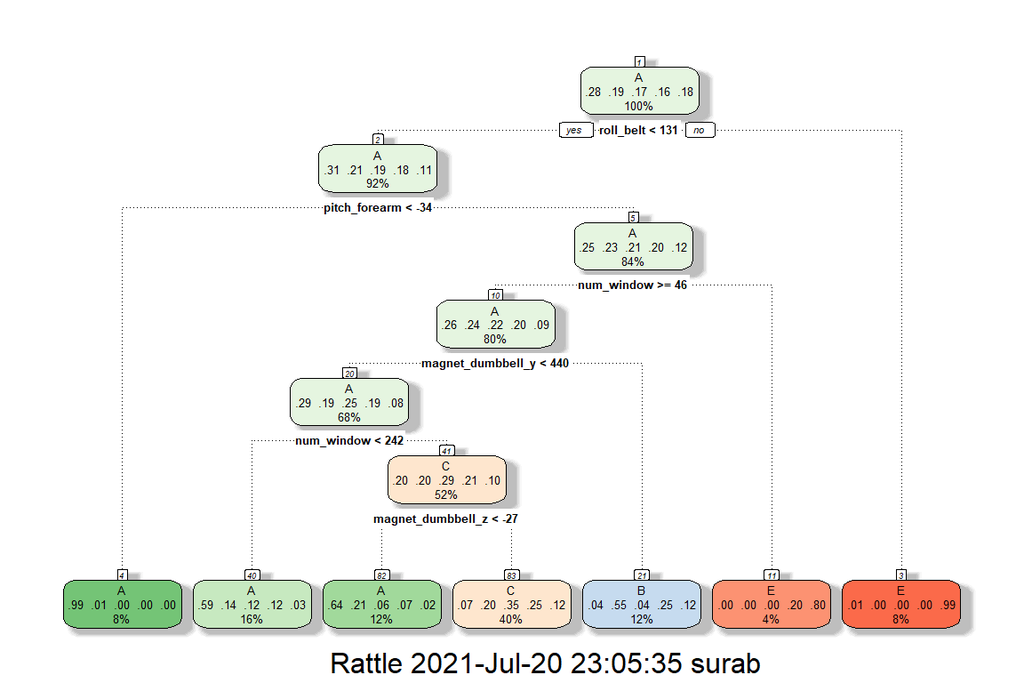

```r
fancyRpartPlot(modelDT$finalModel)
```

```r
predictDT <- predict(modelDT, testSet)
confMatDT <- confusionMatrix(predictDT, testSet$classe)
confMatDT
```

```
## Confusion Matrix and Statistics
##
##           Reference
## Prediction    A    B    C    D    E
##          A 1476  281  145  166   38
##          B   25  401   42  163   89
##          C  169  457  839  591  307
##          D    0    0    0    0    0
##          E    4    0    0   44  648
##
## Overall Statistics
##
##                Accuracy : 0.5716
##                  95% CI : (0.5589, 0.5843)
##     No Information Rate : 0.2845
##     P-Value [Acc > NIR] : < 2.2e-16
##
##                   Kappa : 0.4527
##
##  Mcnemar's Test P-Value : < 2.2e-16
##
## Statistics by Class:
##
##                      Class: A Class: B Class: C Class: D Class: E
## Sensitivity            0.8817  0.35206   0.8177   0.0000   0.5989
## Specificity            0.8504  0.93279   0.6864   1.0000   0.9900
## Pos Pred Value         0.7009  0.55694   0.3551      NaN   0.9310
## Neg Pred Value         0.9476  0.85712   0.9469   0.8362   0.9164
## Prevalence             0.2845  0.19354   0.1743   0.1638   0.1839
## Detection Rate         0.2508  0.06814   0.1426   0.0000   0.1101
## Detection Prevalence   0.3579  0.12234   0.4015   0.0000   0.1183
## Balanced Accuracy      0.8661  0.64242   0.7520   0.5000   0.7944
```

### Random Forest

Configure parallel processing server first. This will help run the Random Forest faster, else it runs too slow.

```r
library(parallel)
library(doParallel)
cluster <- makeCluster(detectCores() - 1) # leave 1 core for OS
registerDoParallel(cluster)
```

```r
library(caret)
set.seed(123)
controlRF <- trainControl(method = "cv", number = 3, verboseIter=FALSE, allowParallel = TRUE)
modelRF <- train(classe ~ ., data = trainSet, method = "rf", trControl = controlRF)
modelRF$finalModel
```

```
##
## Call:
##  randomForest(x = x, y = y, mtry = param$mtry)
##                Type of random forest: classification
##                      Number of trees: 500
## No. of variables tried at each split: 27
##
##         OOB estimate of  error rate: 0.22%
## Confusion matrix:
##      A    B    C    D    E  class.error
## A 3904    1    0    0    1 0.0005120328
## B    5 2649    3    1    0 0.0033860045
## C    0    7 2389    0    0 0.0029215359
## D    0    0    9 2243    0 0.0039964476
## E    0    0    0    3 2522 0.0011881188
```

```r
predictRF <- predict(modelRF, testSet)
confMatRF <- confusionMatrix(predictRF, testSet$classe)
confMatRF
```

```
## Confusion Matrix and Statistics
##
##           Reference
## Prediction    A    B    C    D    E
##          A 1674    3    0    0    0
##          B    0 1136    2    0    2
##          C    0    0 1024    6    0
##          D    0    0    0  958    1
##          E    0    0    0    0 1079
##
## Overall Statistics
##
##                Accuracy : 0.9976
##                  95% CI : (0.996, 0.9987)
##     No Information Rate : 0.2845
##     P-Value [Acc > NIR] : < 2.2e-16
##
##                   Kappa : 0.997
##
##  Mcnemar's Test P-Value : NA
##
## Statistics by Class:
##
##                      Class: A Class: B Class: C Class: D Class: E
## Sensitivity            1.0000   0.9974   0.9981   0.9938   0.9972
## Specificity            0.9993   0.9992   0.9988   0.9998   1.0000
## Pos Pred Value         0.9982   0.9965   0.9942   0.9990   1.0000
## Neg Pred Value         1.0000   0.9994   0.9996   0.9988   0.9994
## Prevalence             0.2845   0.1935   0.1743   0.1638   0.1839
## Detection Rate         0.2845   0.1930   0.1740   0.1628   0.1833
## Detection Prevalence   0.2850   0.1937   0.1750   0.1630   0.1833
## Balanced Accuracy      0.9996   0.9983   0.9984   0.9968   0.9986
```

```r
stopCluster(cluster)
registerDoSEQ()
```

### Generalized Boost Model

```r
library(caret)
set.seed(123)
controlGBM <- trainControl(method = "repeatedcv", number = 3, repeats = 1, verboseIter = FALSE)
modelGBM <- train(classe ~ ., data = trainSet, trControl = controlGBM, method = "gbm", verbose = FALSE)
modelGBM$finalModel
```

```
## A gradient boosted model with multinomial loss function.
## 150 iterations were performed.
## There were 53 predictors of which 53 had non-zero influence.
```

```r
predictGBM <- predict(modelGBM, testSet)
confMatGBM <- confusionMatrix(predictGBM, testSet$classe)
confMatGBM
```

```
## Confusion Matrix and Statistics
##
##           Reference
## Prediction    A    B    C    D    E
##          A 1665    8    0    1    0
##          B    9 1121   15    3    5
##          C    0    9 1008    9    1
##          D    0    1    3  951   12
##          E    0    0    0    0 1064
##
## Overall Statistics
##
##                Accuracy : 0.9871
##                  95% CI : (0.9839, 0.9898)
##     No Information Rate : 0.2845
##     P-Value [Acc > NIR] : < 2.2e-16
##
##                   Kappa : 0.9837
##
##  Mcnemar's Test P-Value : NA
##
## Statistics by Class:
##
##                      Class: A Class: B Class: C Class: D Class: E
## Sensitivity            0.9946   0.9842   0.9825   0.9865   0.9834
## Specificity            0.9979   0.9933   0.9961   0.9967   1.0000
## Pos Pred Value         0.9946   0.9722   0.9815   0.9835   1.0000
## Neg Pred Value         0.9979   0.9962   0.9963   0.9974   0.9963
## Prevalence             0.2845   0.1935   0.1743   0.1638   0.1839
## Detection Rate         0.2829   0.1905   0.1713   0.1616   0.1808
## Detection Prevalence   0.2845   0.1959   0.1745   0.1643   0.1808
## Balanced Accuracy      0.9962   0.9887   0.9893   0.9916   0.9917
```

We use a training sub group to train each of the models and test on a test sub group. We use cross validation as train control parameter in the Random Forest and GBM models. From the 3 models, we see that Random Forest has the highest accuracy on the test sub-group (~99.7%) and that is the model we will pick for our predictions as it has the best out of sample accuracy.

## Final Model Fit on Validation Data

We will now fit the Random Forest model on our validation data set.

```r
predictRFTest <- predict(modelRF, testing)
predictRFTest
```

```
##  [1] B A B A A E D B A A B C B A E E A B B B
## Levels: A B C D E
```